# Chapter 3 Diagnostics and Remedial Measures

Bryan Goodrich

2015-08-08

# Chapter 3 – Diagnostics and Remedial Measures

## Load the data sets

```r
library(MASS)
library(car)
library(lmtest)
data("CH01TA01", package = "ALSM")
data("CH03TA01", package = "ALSM")
data("CH03TA04", package = "ALSM")
data("CH03TA07", package = "ALSM")
data("CH03TA08", package = "ALSM")
data("CH03TA10", package = "ALSM")
```

## Input the Toluca Company Data

```r
.data  <- CH01TA01
names(.data) <- c('x', 'y')
fit <- lm(y ~ x, .data)
```

## FIGURE 3.1 (p 101)

#### Diagnostic Plots for Predictor Variable–Toluca Company Example

```r
par(mfrow = c(2, 2), pch = 19)
stem(.data$x, scale=3)  # Printed to screen, not graphics window
```

```
##
##   The decimal point is 1 digit(s) to the right of the |
##
##    2 | 0
##    3 | 000
##    4 | 00
##    5 | 000
##    6 | 0
##    7 | 000
##    8 | 000
##    9 | 0000
##   10 | 00
##   11 | 00
##   12 | 0
```

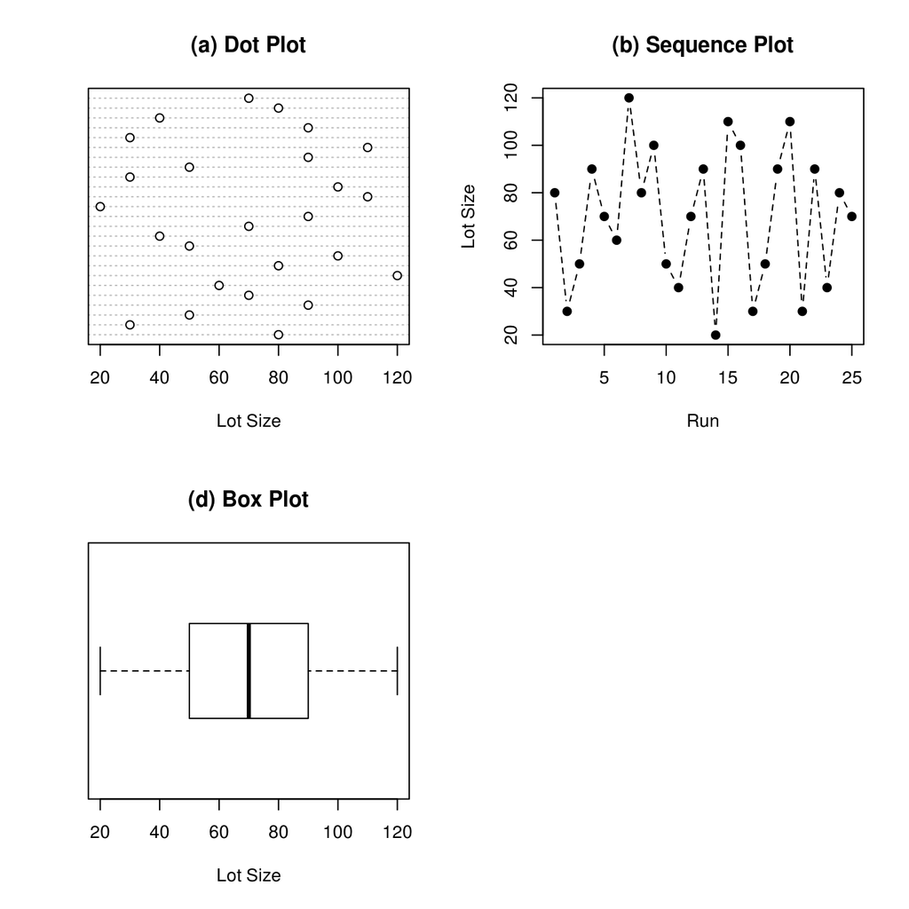

```r
dotchart(.data$x, xlab = "Lot Size", main = "(a) Dot Plot")

plot(.data$x, type = "b", lty = 2, xlab = "Run", ylab = "Lot Size")
title("(b) Sequence Plot")

boxplot(.data$x, horizontal = TRUE, xlab = "Lot Size", main = "(d) Box Plot")
```

## FIGURE 3.2 (p 104)

#### Diagnostic Residual Plots–Toluca Company Example

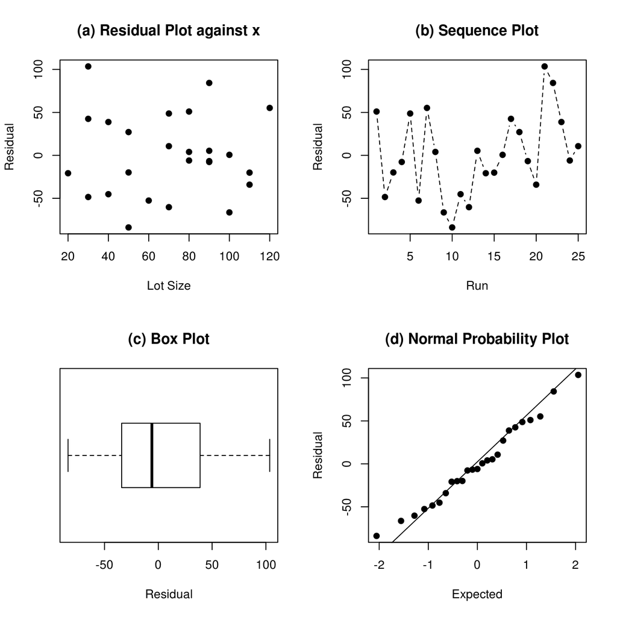

```r
par(mfrow = c(2, 2), pch = 19)

plot(.data$x, resid(fit), xlab = "Lot Size", ylab = "Residual")
title("(a) Residual Plot against x")

plot(resid(fit), type = "b", lty = 2, xlab = "Run", ylab = "Residual")
title("(b) Sequence Plot")

boxplot(resid(fit), horizontal = TRUE, xlab = "Residual")
title("(c) Box Plot")

qqnorm(resid(fit), xlab = "Expected", ylab = "Residual", main = "")
title("(d) Normal Probability Plot")
qqline(resid(fit))
```

## Input The Transit Data

```r
.data <- CH03TA01
names(.data) <- c('y', 'x')
fit <- lm(y ~ x, .data)
```

## FIGURE 3.3 (p 105)

#### Scatter Plot and Residual Plot Illustrating Nonlinear Regression–Transit Example

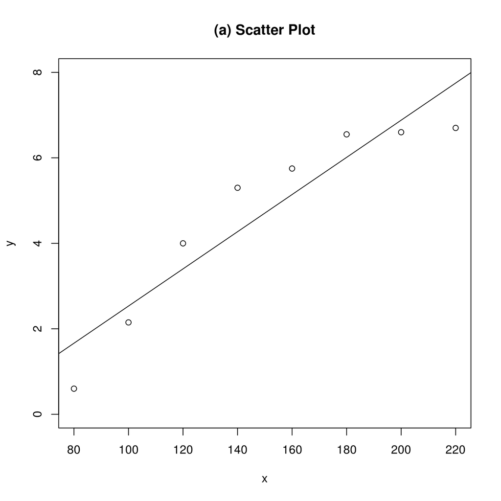

```r
plot(y ~ x, .data, ylim = c(0, 8), main = "(a) Scatter Plot")
abline(fit)
```

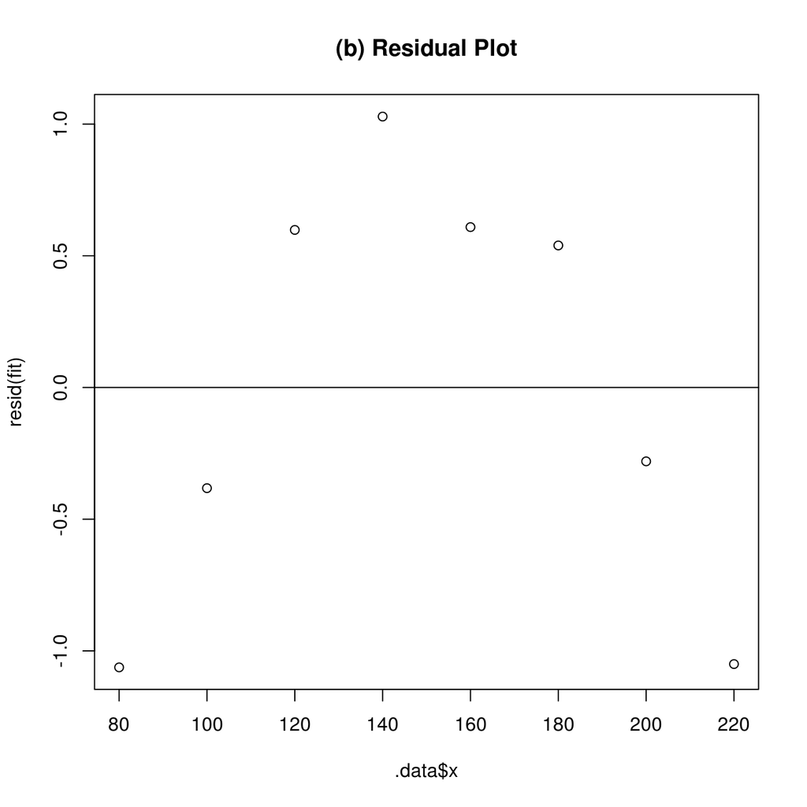

```r
plot(.data$x, resid(fit), main = "(b) Residual Plot")
abline(0, 0)
```

## TABLE 3.1 (p 105)

#### Number of Maps Distributed and Increase in Ridership–Transit Example

```r
cbind(
  "Increase in Ridership" = .data$y,
  "Maps Distributed"      = .data$x,
  "Fitted Values"         = round(fitted(fit), 2),
  "Residuals"             = round(resid(fit), 2))
```

```
##   Increase in Ridership Maps Distributed Fitted Values Residuals
## 1                  0.60               80          1.66     -1.06
## 2                  6.70              220          7.75     -1.05
## 3                  5.30              140          4.27      1.03
## 4                  4.00              120          3.40      0.60
## 5                  6.55              180          6.01      0.54
## 6                  2.15              100          2.53     -0.38
## 7                  6.60              200          6.88     -0.28
## 8                  5.75              160          5.14      0.61
```

## Input Toluca Company Data And Reset Model

```r
.data  <- CH01TA01
names(.data) <- c('x', 'y')
fit <- lm(y ~ x, .data)
```

## TABLE 3.2 (p 111)

#### Residuals and Expected Values under Normality–Toluca Company Example

Could obtain mean square error from model directly using `anova(fit)[2, "Mean Sq"]`. Note that MSE can be calculated below as the `SSE / DF`.

```r
# Expected value under normality comes from equation (3.6)
cbind(
  "Residual"                   = round(resid(fit), 2),
  "Rank"                       = rank(resid(fit)),
  "Exp. Value under Normality" = round(sqrt(deviance(fit) / df.residual(fit)) *
                                       qnorm((rank(resid(fit)) - 0.375) / (nrow(data) + 0.25)), 2))
```

```
##    Residual Rank
## 1     51.02   22
## 2    -48.47    5
## 3    -19.88   10
## 4     -7.68   11
## 5     48.72   21
## 6    -52.58    4
## 7     55.21   23
## 8      4.02   15
## 9    -66.39    2
## 10   -83.88    1
## 11   -45.17    6
## 12   -60.28    3
## 13     5.32   16
## 14   -20.77    8
## 15   -20.09    9
## 16     0.61   14
## 17    42.53   20
## 18    27.12   18
## 19    -6.68   12
## 20   -34.09    7
## 21   103.53   25
## 22    84.32   24
## 23    38.83   19
## 24    -5.98   13
## 25    10.72   17
```

## TABLE 3.3 (p 117)

#### Calculations for Brown-Forsythe Test for Constancy of Error Variance–Toluca Company Example

This complex function will print out the conclusion from the decision rule regarding this test. All of the respective elements are contained within the return object. If this object is not caught, it will display to the screen as displayed below.

For completeness, the *car* library has a levene test function called `leveneTest`. It requires the data have a factor by which to group the observations. This is performed using `cut` on the independent variable. Thus, we use the test on the response variable grouped by the cut independent variable as demonstrated below. The outcome of interest is the p-value which is greater than our alpha. We fail to reject the null hypothesis of equal variance, the same conclusion the authors derived. By default `leveneTest` uses median values (Brown-Forsythe test), and it uses an F-test instead of the t-test. Unfortunately, there is nothing of interest returned with the test object beyond what is displayed.

```r
levene <- function(model, alpha = 0.05)
{
  f <- function(x)
  {
    within(x, {
      dsqdev = scale(abs(e - median(e)), T, F)^2
      d      = abs(e - median(e))
    })
  }  # end f

  data <- model.frame(model)  # Grab the data used in the model
  data <- transform(data,     # Append the residuals and splitting factor
    e = resid(model),
    group = cut(x, 2, labels = LETTERS[1:2]))

  # Split by group factor and add last TABLE 3.3 columns. Notice the syntax for within()
  data.split <- with(data, split(subset(data, select = -group), group))
  data.split <- lapply(data.split, f)


  # Define the relevant variables for hypothesis test and return object
  SSd     <- lapply(data.split, function(x) sum(x$dsqdev))
  dbar    <- lapply(data.split, function(x) mean(x$d))
  n       <- c(Total = nrow(data), lapply(data.split, nrow))   # List of n's
  s       <- sqrt( (SSd$A + SSd$B) / (n$Total - 2) )           # sqrt of (3.9a)
  tstar   <- (dbar$A - dbar$B) / (s * sqrt(1/n$A + 1/n$B))     # (3.9)
  tval    <- qt(1 - alpha/2, n$Total - 2)
  p.value <- 2 * pt(-abs(tval), n$Total - 1)                   # = 0.0495

  # Print conclusion of the decision rule
  if (abs(tstar) <= tval) {
    print("error variance is constant")
  } else
    print("error variance is not constant")

  # return split data and defined variables
  data <- list(
    'data'    = data.split,
    'p.value' = p.value,
    'tstar'   = tstar,
    'tval'    = tval,
    'dbar'    = unlist(dbar),
    'SSd'     = unlist(SSd),
    'n'       = unlist(n),
    's'       = s)

  return(data)
}  # end levene function

levene(fit)
```

```
## [1] "error variance is constant"
```

```
## $data
## $data$A
##      y  x         e           d      dsqdev
## 2  121 30 -48.47192  28.5959596  263.059666
## 3  221 50 -19.87596   0.0000000 2008.390841
## 5  361 70  48.72000  68.5959596  565.530529
## 6  224 60 -52.57798  32.7020202  146.726068
## 10 157 50 -83.87596  64.0000000  368.061393
## 11 160 40 -45.17394  25.2979798  380.916959
## 12 252 70 -60.28000  40.4040404   19.457216
## 14 113 20 -20.76990   0.8939394 1929.066049
## 17 212 30  42.52808  62.4040404  309.371746
## 18 268 50  27.12404  47.0000000    4.773902
## 21 273 30 103.52808 123.4040404 6176.225670
## 23 244 40  38.82606  58.7020202  192.847280
## 25 323 70  10.72000  30.5959596  202.183209
##
## $data$B
##      y   x           e        d      dsqdev
## 1  399  80  51.0179798 53.70202  637.647520
## 4  376  90  -7.6840404  5.00000  549.918291
## 7  546 120  55.2098990 57.89394  866.925740
## 8  352  80   4.0179798  6.70202  472.989271
## 9  353 100 -66.3860606 63.70202 1242.681190
## 13 389  90   5.3159596  8.00000  418.216271
## 15 435 110 -20.0880808 17.40404  122.020662
## 16 420 100   0.6139394  3.29798  632.641058
## 19 377  90  -6.6840404  4.00000  597.818965
## 20 421 110 -34.0880808 31.40404    8.724366
## 22 468  90  84.3159596 87.00000 3428.063073
## 24 342  80  -5.9820202  3.29798  632.641058
##
##
## $p.value
## [1] 0.0495146
##
## $tstar
## [1] 1.316482
##
## $tval
## [1] 2.068658
##
## $dbar
##        A        B
## 44.81507 28.45034
##
## $SSd
##         A         B
## 12566.611  9610.287
##
## $n
## Total     A     B
##    25    13    12
##
## $s
## [1] 31.05178
```

```r
with(.data, leveneTest(y, cut(x, 2)))  # F value is within acceptance region
```

```
## Levene's Test for Homogeneity of Variance (center = median)
##       Df F value Pr(>F)
## group  1  0.7785 0.3867
##       23
```

## Breusch-Pagan Test (p 118)

R has a method for calculating this contained in the *lmtest* library. It defaults to a studentized BP test, so an extra parameter will be passed.

Note: The authors have retained an error in this 5th edition since the 4th. They claim a p-value of `0.64 > alpha` which is inconsistent with their results and the outcome of the `bptest` command. The true p-value provided appears to be `1 - 0.64 = 0.36`.

```r
bptest(fit, student = FALSE)
```

```
##
##  Breusch-Pagan test
##
## data:  fit
## BP = 0.82092, df = 1, p-value = 0.3649
```

```r
qchisq(1 - 0.05, 1) # BP falls within the chisq acceptance region
```

```
## [1] 3.841459
```

## Input the Bank Data

```r
.data <- CH03TA04
names(.data) <- c('x', 'y')
fit <- lm(y ~ x, .data)
```

## TABLE 3.4 (p 120)

#### Data and Analysis of Variance Table–Bank Example

```r
as.table(cbind(
  "Size of Min. Deposit"   = .data$x,
  "Number of New Accounts" = .data$y
))
```

```
##   Size of Min. Deposit Number of New Accounts
## A                  125                    160
## B                  100                    112
## C                  200                    124
## D                   75                     28
## E                  150                    152
## F                  175                    156
## G                   75                     42
## H                  175                    124
## I                  125                    150
## J                  200                    104
## K                  100                    136
```

```r
anova(fit)
```

```
## Analysis of Variance Table
##
## Response: y
##           Df  Sum Sq Mean Sq F value Pr(>F)
## x          1  5141.3  5141.3  3.1389 0.1102
## Residuals  9 14741.6  1638.0
```

## FIGURE 3.11 (p 121)

#### Scatter Plot and Fitted Regression Line–Bank Example

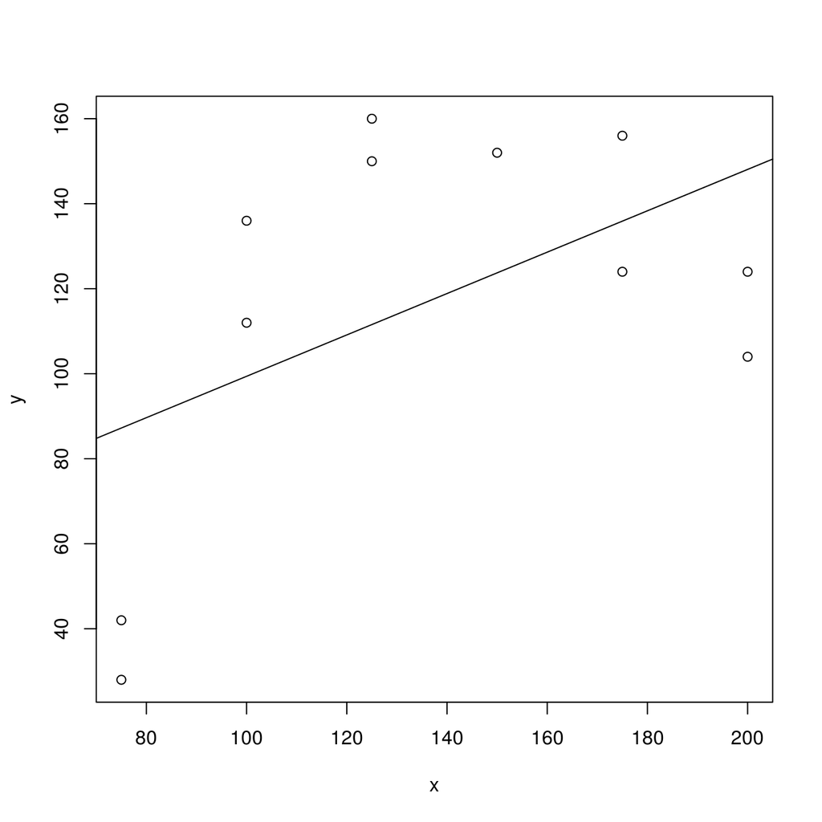

```r
plot(y ~ x, .data)
abline(fit)
```

## TABLE 3.5 (p 121)

#### Data Arranged by Replicate Number and Minimum Deposit–Bank Example

```r
tab           <- do.call("cbind", unstack(.data, y ~ x))
tab[2, 4]     <- NA  # The singular "150" level value is duplicated; remove it
tab           <- rbind(tab, colMeans(tab, na.rm = TRUE))
dimnames(tab) <- list(Replicate = c(1:2, "Mean"), Deposit = dimnames(tab)[[2]])
(tab          <- as.table(tab))
```

```
##          Deposit
## Replicate  75 100 125 150 175 200
##      1     28 112 160 152 156 124
##      2     42 136 150     124 104
##      Mean  35 124 155 152 140 114
```

## TABLE 3.6 (p 126)

#### General ANOVA Table for Testing Lack of Fit of Simple Linear Regression Function and ANOVA Table–Bank Example

While R has a basic anova table for lm objects, there is a trick to obtain a further decomposition for the lack of fit and pure error. In particular, with a `y ~ x` regression, we can model `y ~ x + factor(x)` to obtain an anova table with the desired values. Also, the *alr3* package contains a function pureErrorAnova that gives a more complete anova table.

For numeric subscripting, the following will be utilized

```
   Number    Rows                      Columns
   1         x         (Regression)    Df
   2         factor(x) (lack of fit)   Sum Sq
   3         Residuals (pure error)    Mean Sq
```

```r
fit.aov <- anova(update(fit, . ~ . + factor(x)))
as.table(cbind(
  'SS' = c('SSR'   =     fit.aov[1,   2],
           'SSE'   = sum(fit.aov[2:3, 2]),
           'SSLF'  =     fit.aov[2,   2],
           'SSPE'  =     fit.aov[3,   2],
           'Total' = sum(fit.aov[1:3, 2])),

  'Df' = c(              fit.aov[1,   1],
                     sum(fit.aov[2:3, 1]),
                         fit.aov[2,   1],
                         fit.aov[3,   1],
                     sum(fit.aov[1:3, 1])),

  'MS' = c(              fit.aov[1,   3],
                     sum(fit.aov[2:3, 2]) / sum(fit.aov[2:3, 1]),
                         fit.aov[2,   3],
                         fit.aov[3,   3],
                         NA)
))
```

```
##              SS        Df        MS
## SSR    5141.338     1.000  5141.338
## SSE   14741.571     9.000  1637.952
## SSLF  13593.571     4.000  3398.393
## SSPE   1148.000     5.000   229.600
## Total 19882.909    10.000
```

## Input the Sales Training data

```r
.data <- CH03TA07
names(.data) <- c('x', 'y')
fit <- lm(y ~ x, .data)
```

## TABLE 3.7 (p 130)

#### Use of Square Root Transformation of X to Linearize Regression Relation–Sales Training Example

```r
(.data <- transform(.data, sqrtx = sqrt(x)))
```

```
##      x     y     sqrtx
## 1  0.5  42.5 0.7071068
## 2  0.5  50.6 0.7071068
## 3  1.0  68.5 1.0000000
## 4  1.0  80.7 1.0000000
## 5  1.5  89.0 1.2247449
## 6  1.5  99.6 1.2247449
## 7  2.0 105.3 1.4142136
## 8  2.0 111.8 1.4142136
## 9  2.5 112.3 1.5811388
## 10 2.5 125.7 1.5811388
```

## FIGURE 3.14 (p 131)

#### Scater Plots and Residual Plots–Sales Training Example

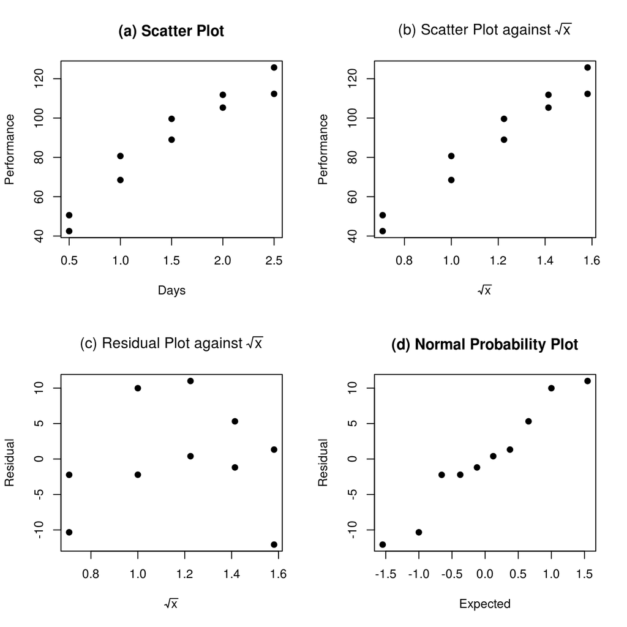

```r
par(mfrow = c(2, 2), pch = 19)
plot(y ~ x, .data, xlab = "Days", ylab = "Performance")
title("(a) Scatter Plot")

plot(y ~ sqrt(x), .data, xlab = expression(sqrt(x)), ylab = "Performance")
title(expression(paste("(b) Scatter Plot against ", sqrt(x))))

plot(resid(fit) ~ sqrt(x), .data, xlab = expression(sqrt(x)), ylab = "Residual")
title(expression(paste("(c) Residual Plot against ", sqrt(x))))

qqnorm(resid(fit), xlab = "Expected", ylab = "Residual", main = "")
title("(d) Normal Probability Plot")
```

## Input the Plasma Levels data

```r
.data <- CH03TA08
names(.data) <- c("x", "y", "z")
fit <- lm(z ~ x, .data)
```

## TABLE 3.8 (p 133)

#### Use of Logarithmic Transformation of Y to Linearize Regression Relation and Stabilize Error Variance–Plasma Levels Example

```r
with(.data, data.frame("Age" = x, "Plasma" = y, "Transform" = z))
```

```
##    Age Plasma Transform
## 1    0  13.44    1.1284
## 2    0  12.84    1.1086
## 3    0  11.91    1.0759
## 4    0  20.09    1.3030
## 5    0  15.60    1.1931
## 6    1  10.11    1.0048
## 7    1  11.38    1.0561
## 8    1  10.28    1.0120
## 9    1   8.96    0.9523
## 10   1   8.59    0.9340
## 11   2   9.83    0.9926
## 12   2   9.00    0.9542
## 13   2   8.65    0.9370
## 14   2   7.85    0.8949
## 15   2   8.88    0.9484
## 16   3   7.94    0.8998
## 17   3   6.01    0.7789
## 18   3   5.14    0.7110
## 19   3   6.90    0.8388
## 20   3   6.77    0.8306
## 21   4   4.86    0.6866
## 22   4   5.10    0.7076
## 23   4   5.67    0.7536
## 24   4   5.75    0.7597
## 25   4   6.23    0.7945
```

## FIGURE 3.16 (p 134)

#### Scatter Plots and Residual Plots–Plasma Levels Example

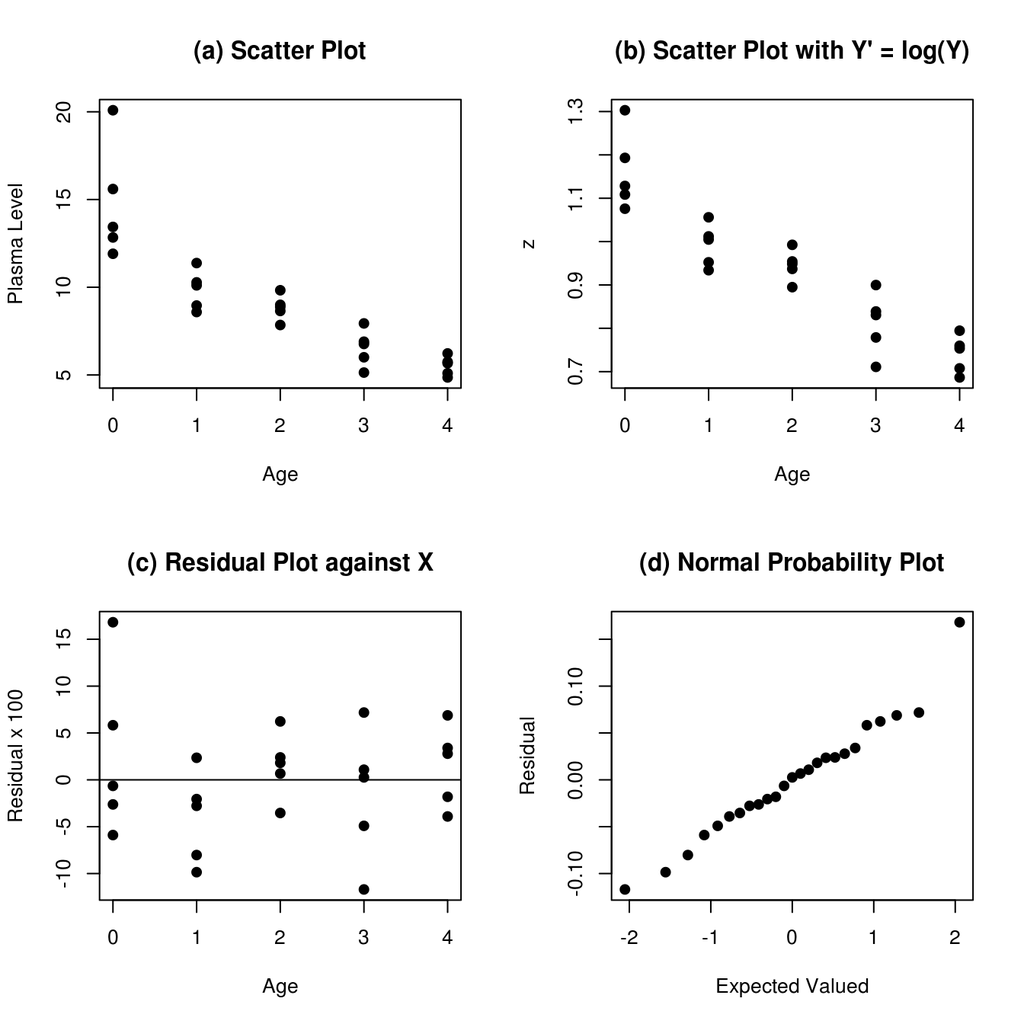

```r
par(mfrow = c(2, 2), pch = 19)
plot(y ~ x, .data, xlab = "Age", ylab = "Plasma Level")
title("(a) Scatter Plot")

plot(z ~ x, .data, xlab = "Age")
title("(b) Scatter Plot with Y' = log(Y)")

plot(.data$x, resid(fit)*100, xlab = "Age", ylab = "Residual x 100")
title("(c) Residual Plot against X")
abline(0, 0)

qqnorm(resid(fit), xlab = "Expected Valued", ylab = "Residual", main = "")
title("(d) Normal Probability Plot")
```

## TABLE 3.9 and Figure 3.17 (p 136)

#### Box-Cox Results–Plasma Levels Example

R has two Box-Cox functions: `boxcox` (*MASS*) and `boxCox` (*car*). They both take a linear model object as their input. They both produce a graph that maximizes the log-likelihood rather than minimize the sum of squares error. The result is the same.

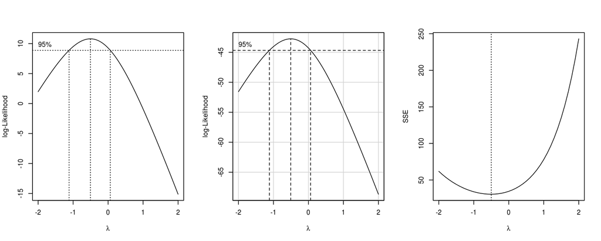

```r
par(mfrow = c(1, 3))
boxcox(lm(y ~ x, .data))
boxCox(lm(y ~ x, .data))
boxcox.sse <- function(lambda, model)
{
  x  <- model.frame(model)$x
  y  <- model.frame(model)$y
  K2 <- prod(y)^( 1/length(y) )            # (3.36a)
  K1 <- 1 / (lambda * K2^(lambda - 1))     # (3.36b)
  ifelse(lambda != 0,                      # (3.36)
    assign("W", K1 * (y^lambda - 1)),
    assign("W", K2 * log(y)))

  # Deviance = Residual Sum of Squares
  return(deviance(lm(W ~ x)))
}

lambda <- seq(-2, 2, by = 0.1)
SSE = sapply(lambda, boxcox.sse, lm(y ~ x, .data))
plot(lambda, SSE, type = "l", xlab = expression(lambda))
abline(v = -0.5, lty = 3)
```

```r
cbind('lambda' = lambda, 'SSE' = SSE)
```

```
##       lambda       SSE
##  [1,]   -2.0  61.85640
##  [2,]   -1.9  57.57287
##  [3,]   -1.8  53.66783
##  [4,]   -1.7  50.11904
##  [5,]   -1.6  46.90689
##  [6,]   -1.5  44.01425
##  [7,]   -1.4  41.42638
##  [8,]   -1.3  39.13089
##  [9,]   -1.2  37.11767
## [10,]   -1.1  35.37886
## [11,]   -1.0  33.90887
## [12,]   -0.9  32.70442
## [13,]   -0.8  31.76453
## [14,]   -0.7  31.09066
```

[output cut: 27 more lines]

## Input the Toluca Company Data

```r
.data <- CH01TA01
names(.data) <- c('x', 'y')
fit  <- lm(y ~ x, .data)
```

## FIGURE 3.19 (p 140)

#### Lowess Curve and Confidence Band for Regression Line–Toluca Company Example

R has methods for lowess regression (`loess`) and loess plotting. We will simply make use of these faculties. As stated in the Chapter 2 walk-through we will plot confidence bands using the built-in R function predict. The R function `scatter.smooth` plots both the scatter plot and lowess curve. `FIGURE 3.18` will be ignored since it can be generated in the same manner.

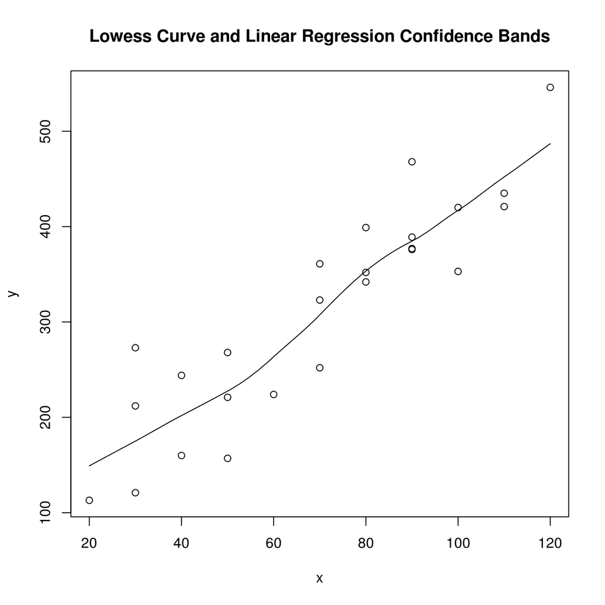

```r
with(.data, scatter.smooth(x, y))
title("Lowess Curve and Linear Regression Confidence Bands")
```

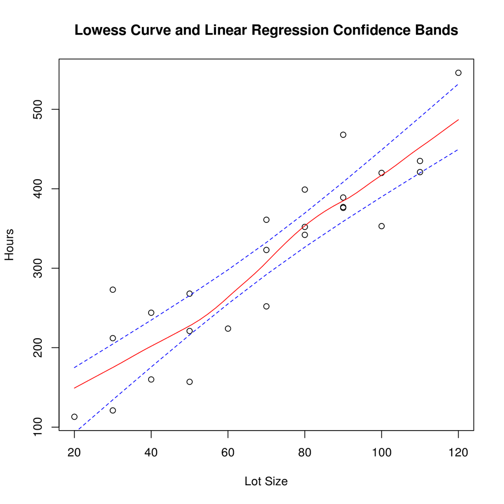

```r
plot(y ~ x, .data, xlab = "Lot Size", ylab = "Hours")
title("Lowess Curve and Linear Regression Confidence Bands")
with(.data, lines(loess.smooth(x, y), col = "red"))

# Gather confidence bands, ordered by x, and add lines to plot
ci <- cbind(model.frame(fit), predict(fit, int = "c"))[order(.data$x), ]
lines(lwr ~ x, ci, col = "blue", lty = "dashed" )
lines(upr ~ x, ci, col = "blue", lty = "dashed" )
```

## Input the Plutonium Measurement Data

```r
.data <- CH03TA10
names(.data) <- c("y", "x")
```

## TABLE 3.10 (p 141)

#### Basic Data–Plutonium Measurement Example

```r
cbind("Plutonium Activity" = .data$x, "Alpha Count Rate" = .data$y)
```

```
##       Plutonium Activity Alpha Count Rate
##  [1,]                 20            0.150
##  [2,]                  0            0.004
##  [3,]                 10            0.069
##  [4,]                  5            0.030
##  [5,]                  0            0.011
##  [6,]                  0            0.004
##  [7,]                  5            0.041
##  [8,]                 20            0.109
##  [9,]                 10            0.068
## [10,]                  0            0.009
## [11,]                  0            0.009
## [12,]                 10            0.048
## [13,]                  0            0.006
## [14,]                 20            0.083
## [15,]                  5            0.037
## [16,]                  5            0.039
## [17,]                 20            0.132
## [18,]                  0            0.004
## [19,]                  0            0.006
## [20,]                 10            0.059
## [21,]                 10            0.051
## [22,]                  0            0.002
## [23,]                  5            0.049
## [24,]                  0            0.106
```

## FIGURE 3.20 (p 142)

#### Scatter Plot and Lowess Smoothed Curve–Plutonium Measurement Example

Analytically confirm nonconstant variance by the BP test

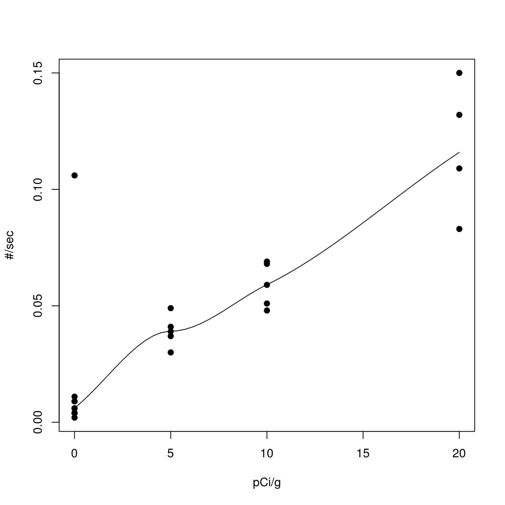

```r
plot(y ~ x, .data, pch = 19, xlab = "pCi/g", ylab = "#/sec")
with(.data, lines(loess.smooth(x, y)))  # Warnings may occur
```

```r
c(Stat  = bptest(lm(y ~ x, .data), student = FALSE)$statistic,
  Chisq = pchisq(.95, 1))  # BP falls outside acceptance region: Reject H0
```

```
##   Stat.BP     Chisq
## 0.7507850 0.6702807
```

## FIGURE 3.21 FIGURE 3.22 and FIGURE 3.23 (p 143-5)

#### Regression Output and Diagnostic Plots–Plutonium Measurement Example

```r
.data <- .data[-24, ]  # Remove outlier: Record 24
.data <- transform(.data, sqrty = sqrt(y), sqrtx = sqrt(x))

# Linear Models Summay and Anova
summary(lm(y ~ x, .data))
```

```
##
## Call:
## lm(formula = y ~ x, data = .data)
##
## Residuals:
##       Min        1Q    Median        3Q       Max
## -0.034773 -0.004061 -0.001033  0.004939  0.032227
##
## Coefficients:
##              Estimate Std. Error t value Pr(>|t|)
## (Intercept) 0.0070331  0.0035988   1.954   0.0641 .
## x           0.0055370  0.0003659  15.133 9.08e-13 ***
## ---
## Signif. codes:  0 '***' 0.001 '**' 0.01 '*' 0.05 '.' 0.1 ' ' 1
##
## Residual standard error: 0.01257 on 21 degrees of freedom
## Multiple R-squared:  0.916,  Adjusted R-squared:  0.912
## F-statistic:   229 on 1 and 21 DF,  p-value: 9.077e-13
```

```r
anova(lm(y ~ x, .data))
```

```
## Analysis of Variance Table
##
## Response: y
##           Df   Sum Sq  Mean Sq F value    Pr(>F)
## x          1 0.036190 0.036190     229 9.077e-13 ***
## Residuals 21 0.003319 0.000158
## ---
## Signif. codes:  0 '***' 0.001 '**' 0.01 '*' 0.05 '.' 0.1 ' ' 1
```

```r
summary(lm(sqrty ~ x, .data))
```

```
##
## Call:
## lm(formula = sqrty ~ x, data = .data)
##
## Residuals:
##       Min        1Q    Median        3Q       Max
## -0.073958 -0.024407  0.000109  0.028007  0.059776
##
## Coefficients:
##              Estimate Std. Error t value Pr(>|t|)
## (Intercept) 0.0947596  0.0095668   9.905 2.29e-09 ***
## x           0.0133648  0.0009727  13.740 5.77e-12 ***
## ---
## Signif. codes:  0 '***' 0.001 '**' 0.01 '*' 0.05 '.' 0.1 ' ' 1
##
## Residual standard error: 0.03342 on 21 degrees of freedom
## Multiple R-squared:  0.8999, Adjusted R-squared:  0.8951
## F-statistic: 188.8 on 1 and 21 DF,  p-value: 5.767e-12
```

```r
anova(lm(sqrty ~ x, .data))
```

```
## Analysis of Variance Table
##
## Response: sqrty
##           Df   Sum Sq  Mean Sq F value    Pr(>F)
## x          1 0.210847 0.210847   188.8 5.767e-12 ***
## Residuals 21 0.023453 0.001117
## ---
## Signif. codes:  0 '***' 0.001 '**' 0.01 '*' 0.05 '.' 0.1 ' ' 1
```

```r
summary(lm(sqrty ~ sqrtx, .data))
```

```
##
## Call:
## lm(formula = sqrty ~ sqrtx, data = .data)
##
## Residuals:
##       Min        1Q    Median        3Q       Max
## -0.041186 -0.010541  0.000868  0.014336  0.058015
##
## Coefficients:
##             Estimate Std. Error t value Pr(>|t|)
## (Intercept) 0.073006   0.007831   9.323 6.51e-09 ***
## sqrtx       0.057305   0.003016  18.998 1.05e-14 ***
## ---
## Signif. codes:  0 '***' 0.001 '**' 0.01 '*' 0.05 '.' 0.1 ' ' 1
##
## Residual standard error: 0.02477 on 21 degrees of freedom
## Multiple R-squared:  0.945,  Adjusted R-squared:  0.9424
## F-statistic: 360.9 on 1 and 21 DF,  p-value: 1.046e-14
```

```r
anova(lm(sqrty ~ sqrtx, .data))
```

```
## Analysis of Variance Table
##
## Response: sqrty
##           Df   Sum Sq  Mean Sq F value    Pr(>F)
## sqrtx      1 0.221416 0.221416  360.92 1.046e-14 ***
## Residuals 21 0.012883 0.000613
## ---
## Signif. codes:  0 '***' 0.001 '**' 0.01 '*' 0.05 '.' 0.1 ' ' 1
```

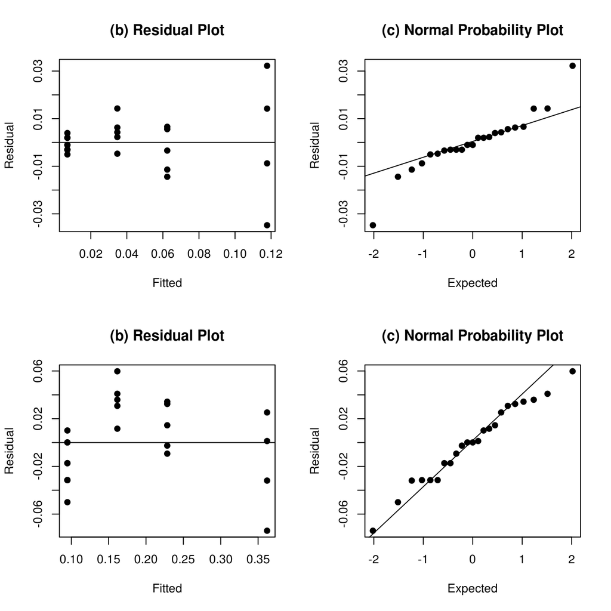

```r
pplot <- function(formula, data)
{
  fit <- lm(formula, data)
  plot(resid(fit) ~ fitted(fit), xlab = "Fitted", ylab = "Residual")
  title("(b) Residual Plot")
  abline(0, 0)

  qqnorm(resid(fit), xlab = "Expected", ylab = "Residual", main = "")
  qqline(resid(fit))
  title("(c) Normal Probability Plot")
}

par(mfrow = c(2, 2), pch = 19)
pplot(y ~ x, .data)          # Untransformed Plots (FIGURE 3.21)
pplot(sqrty ~ x, .data)      # Transformed Response Plots (FIGURE 3.22)
```

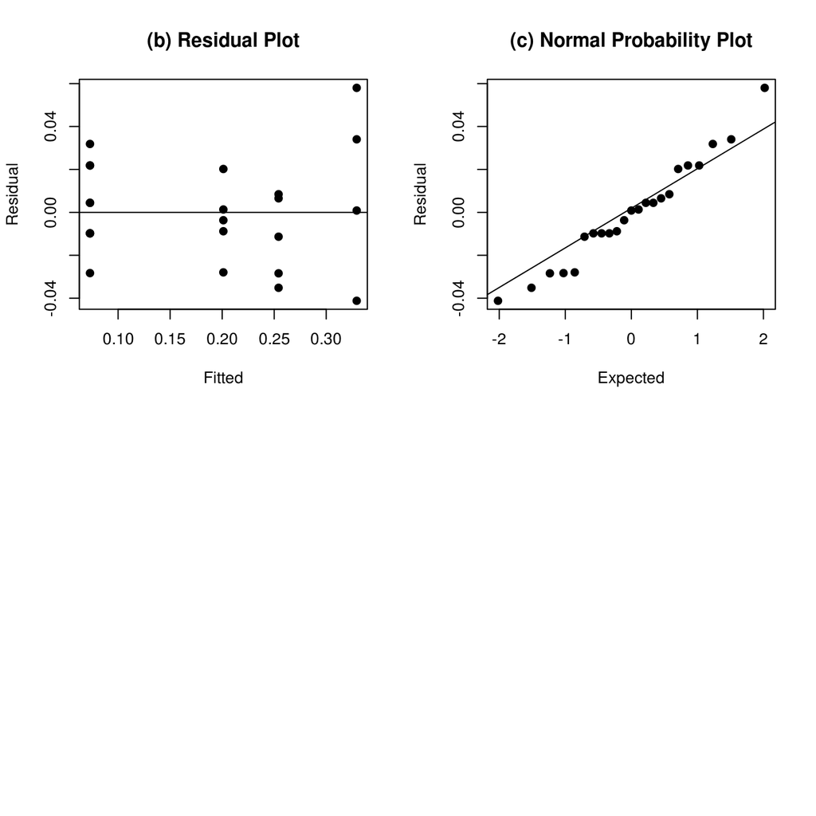

```r
pplot(sqrty ~ sqrtx, .data)  # Transformed Response and Predictor Plots (FIGURE 3.23)


par(mfrow = c(1,1))
```

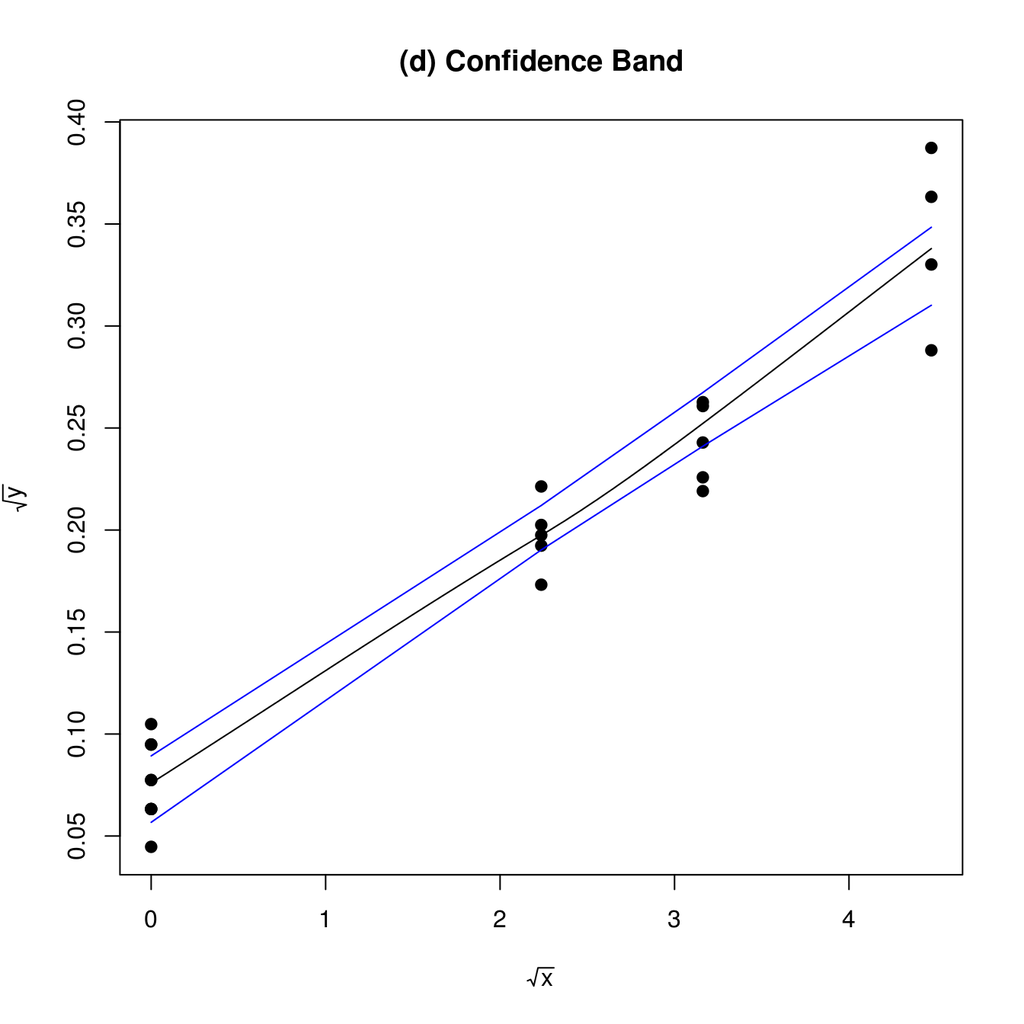

```r
fit <- lm(sqrty ~ sqrtx, .data)
scatter.smooth(.data$sqrtx, .data$sqrty, main = "(d) Confidence Band", pch = 19,
               xlab = expression(sqrt(x)), ylab = expression(sqrt(y)))

newdata = data.frame(sqrtx = sort(.data$sqrtx))
pp <- predict(fit, newdata, int = "c")
lines(newdata$sqrtx, pp[, 2], col = "blue")
lines(newdata$sqrtx, pp[, 3], col = "blue")
```